# Joey Kilgore

PhD Student studying Computer Engineering specializing in Biologically Inspired Artificial Intelligence at George Washington University.

[figure not shown]

# Education

## Bachelor's of Science

#### Computer Science and Engineering

Completed in Spring 2021 at the University of Toledo

## Associate of Science with Honors

Completed in Spring 2020 at Lorain County Community College

# Experience

#### Case Western Reserve University

- Modeled and ran simulations using NEURON
- Recreated results of other research groups
- Setup source control for multiple projects
- Presented original research ideas to a group of 5 other researchers

## Peer Mentor (08-2020 to 05-2021)

#### University of Toledo

- Ran a 3000-level Embedded Systems lab
- Ran a 1000-level Introduction to CSE lab
- Graded lab reports and homework documents
- Answered questions and guided students through projects

## Sofware Development Intern (05-2018 to 08-2018)

#### Hyland Software

- Updated an ASP.NET web application
- Participated in Agile development, including a Scrum
- Worked with SQL Database

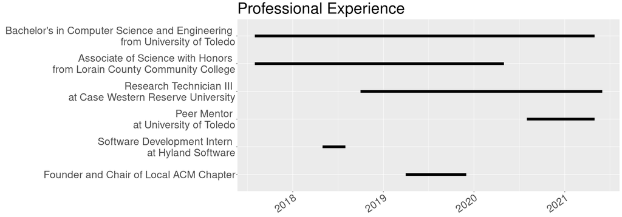

```r
show(exp_plot)
```

# Publications

Eggers, T., Kilgore, J., Green, D., Vrabec, T., Kilgore, K., & Bhadra, N. (2021). Combining direct current and kilohertz frequency alternating current to mitigate onset activity during electrical nerve block. Journal of Neural Engineering, 18(4), 046010. https://doi.org/10.1088/1741-2552/abebed

[Google Scholar](https://scholar.google.com/citations?user=UBzRtLoAAAAJ&hl=en)

# Additional Links

For all of my current coding projects checkout [my github](https://github.com/joey-kilgore)

Checkout my Linkedin for where I'm currently working and connect with me [here](https://www.linkedin.com/in/joey-kilgore/)

# Additional Graphs

Recently I have been working on CoViD-19 Data Analysis and have a repository setup for that [here](https://github.com/joey-kilgore/COVID-19-Data-Visualization)

[figure not shown]

```r
# Code for Professional Experience Graph
library(ggplot2)
options(repr.plot.width = 20, repr.plot.height = 7, repr.plot.res = 100)
exp <- read.csv("./experience.csv")
exp$Start <- as.Date(paste0(exp$Start, "-01"), "%m-%Y-%d")
exp$End <- as.Date(paste0(exp$End, "-01"), "%m-%Y-%d")
exp$Experience <- sub("/n","\n",exp$Experience)
exp_plot <- ggplot(data=exp)+geom_segment(aes(x=Start,xend=End,
        y=reorder(Experience,-Precedence), yend=reorder(Experience,-Precedence)), size=3)+
    ggtitle("Professional Experience")+
    theme(text = element_text(size=30),
        axis.text.x = element_text(angle=35, hjust=1),
        axis.text.y = element_text(angle=0, hjust=1),
         axis.title.y = element_blank(),
         axis.title.x = element_blank())
```